# Projet

Beogo Eric

05 Mai 2017

# Presentation de la base de données

La base de donn?es que nous allons utilis?e est du domaine sociale,il s’agit de la base “Drug consumption” tir?e du site archive.ics.uci.edu/ml/datasets ,les auteurs sont: . Elaine Fehrman, (Trouble de la personnalité masculine et Direction nationale des femmes, Rampton Hospital, Retford) . Vincent Egan, (Département de psychiatrie et de psychologie appliquée, Universit? de Nottingham) . Evgeny M. Mirkes (Department de Mathematiques, Universit? de Leicester).

La base contient 1885 observations (qui sont 1885 individus interog?s) et 32 variables reels sans valeures manquantes.Toutes les variables sont initialement cat?gorielles et sont quantifiées. Apr?s quoi elles peuvent être consid?r?es comme r?elles. En outre, les participants ont ?t? interrog?s concernant leur utilisation de 18 drogues l?gales et ill?gales et pour chaque individu, on connait certaines mesures de personalit? et aussi le niveau d’?ducation, L’?ge, le sexe, le pays de r?sidence et l’appartenance ethnique. Pour notree etude, nous allons nous contenter d’etudier 14 variables que sont : age, gender, education, ethnicity, Nscore, Escore, Oscore, Ascore, Cscore, Impulsive, Alcohol, amphet, caff, heroin.

## Apercu de nos donn?es:

```r
d=d[,c(2,3,4,6,7,8,9,10,11,12,14,15,18,24)]
colnames(d)=c("Age","Gender","Education","Ethnicity","Nscore","Escore","Oscore","Ascore","Cscore","Impulsive","Alcohol","Amphet","Caff","Heroin")
head(d)
```

```
##        Age   Gender Education Ethnicity   Nscore   Escore   Oscore
## 1  0.49788  0.48246  -0.05921   0.12600  0.31287 -0.57545 -0.58331
## 2 -0.07854 -0.48246   1.98437  -0.31685 -0.67825  1.93886  1.43533
## 3  0.49788 -0.48246  -0.05921  -0.31685 -0.46725  0.80523 -0.84732
## 4 -0.95197  0.48246   1.16365  -0.31685 -0.14882 -0.80615 -0.01928
## 5  0.49788  0.48246   1.98437  -0.31685  0.73545 -1.63340 -0.45174
## 6  2.59171  0.48246  -1.22751  -0.31685 -0.67825 -0.30033 -1.55521
##     Ascore   Cscore Impulsive Alcohol Amphet Caff Heroin
## 1 -0.91699 -0.00665  -0.21712     CL5    CL2  CL6    CL0
## 2  0.76096 -0.14277  -0.71126     CL5    CL2  CL6    CL0
## 3 -1.62090 -1.01450  -1.37983     CL6    CL0  CL6    CL0
## 4  0.59042  0.58489  -1.37983     CL4    CL0  CL5    CL0
## 5 -0.30172  1.30612  -0.21712     CL4    CL1  CL6    CL0
## 6  2.03972  1.63088  -1.37983     CL2    CL0  CL6    CL0
```

# Description des variables d’etude

### Age

Il s’agit de l’age des individus;on a 6 valeures et à chaque valeure, correspond une classe d’age: -0.95197 pour 18-24ans, -0.07854 pour 25-34ans, 0.49788 pour 35-44ans, 1.09449 pour 45-54ans , 1.82213 pour 55-64ans et 2.59171 pour 65ans et +

```r
summary(d$Age)
```

```
##     Min.  1st Qu.   Median     Mean  3rd Qu.     Max.
## -0.95197 -0.95197 -0.07854  0.03461  0.49788  2.59171
```

```r
table(d$Age)
```

```
##
## -0.95197 -0.07854  0.49788  1.09449  1.82213  2.59171
##      643      481      356      294       93       18
```

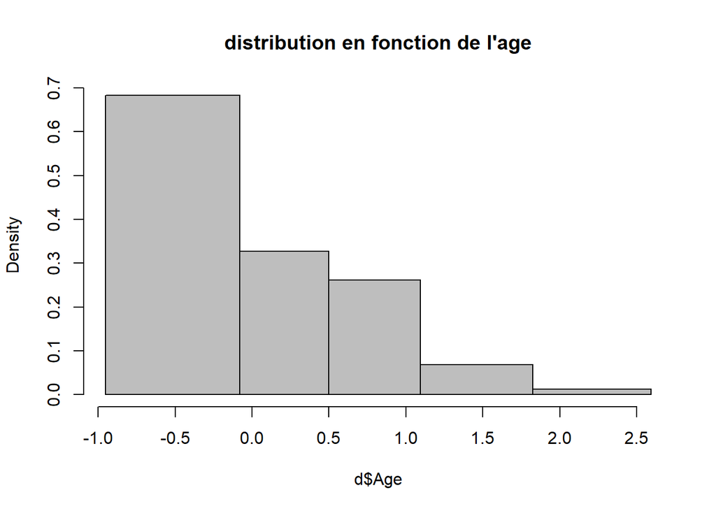

```r
hist(d$Age, breaks = c(-0.95197,-0.07854,0.49788,1.09449,1.82213,2.59171),col ="gray", main ="distribution en fonction de l'age")
```

### Gender

Comme son nom l’indique, cette variable precise le sexe des individus, comme suite 0.48246 pour Femme et -0.48246 pour Homme.

```r
table(d$Gender)
```

```
##
## -0.48246  0.48246
##      943      942
```

On a pratiquement le meme nombrede femme et d’homme dans la population.

### Education

Elle indique le niveau d’etude des individus comme suite: -2.43591 pour un individu qui a quitt? l’Ecole avant 16 ans, -1.73790 pour un individu qui a quitt? l’Ecole ? 16 ans, -1.43719 pour un individu qui a quitt? l’Ecole ? 17 ans, -1.22751 pour un individu qui a quitt? l’Ecole ? 18 ans, -0.61113 pour un individu qui est ? un niveau collège ou une université, sans certificat ni diplome, -0.05921 pour un individu qui a un Certificat professionnel / diplôme, 0.45468 pour un individu qui a un Diplôme universitaire, 1.16365 pour un individu qui a une Maîtrise, 1.98437 pour un individu qui a un Doctorat.

```r
summary(d$Education)
```

```
##      Min.   1st Qu.    Median      Mean   3rd Qu.      Max.
## -2.435910 -0.611130 -0.059210 -0.003806  0.454680  1.984370
```

```r
table(d$Education)
```

```
##
## -2.43591  -1.7379 -1.43719 -1.22751 -0.61113 -0.05921  0.45468  1.16365
##       28       99       30      100      506      270      480      283
##  1.98437
##       89
```

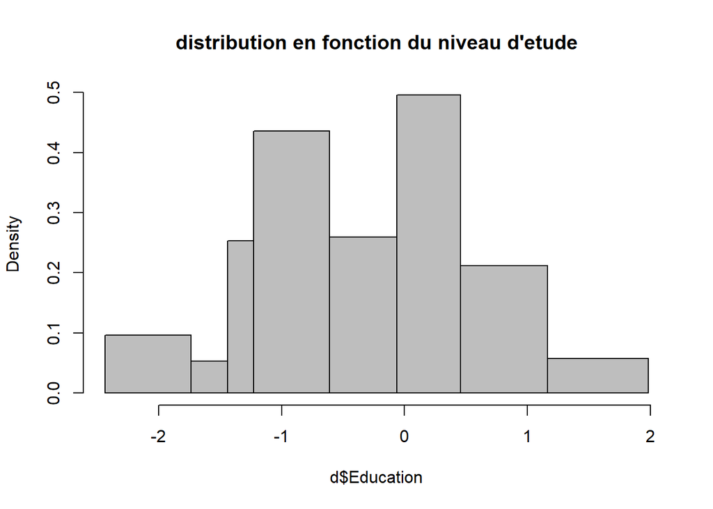

```r
hist(d$Education,breaks = c(-2.43591,-1.73790,-1.43719,-1.22751,-0.61113,-0.05921,0.45468,1.16365,1.98437),main="distribution en fonction du niveau d'etude", col='gray')
```

### Ethnicity

elle indique l’appartenance ethnique,selon les valeures suivantes on a: -0.50212 pour Asiatique , -1.10702 pour noir, 1.90725 pour metisse noire/asiatique, 0.12600 pour metisse noir/asiatique, -0.22166 pour metisse blanc/noir, 0.11440 pour autres et -0.31685 pour blanc.

```r
table(d$Ethnicity)
```

```
##
## -1.10702 -0.50212 -0.31685 -0.22166   0.1144    0.126  1.90725
##       33       26     1720       20       63       20        3
```

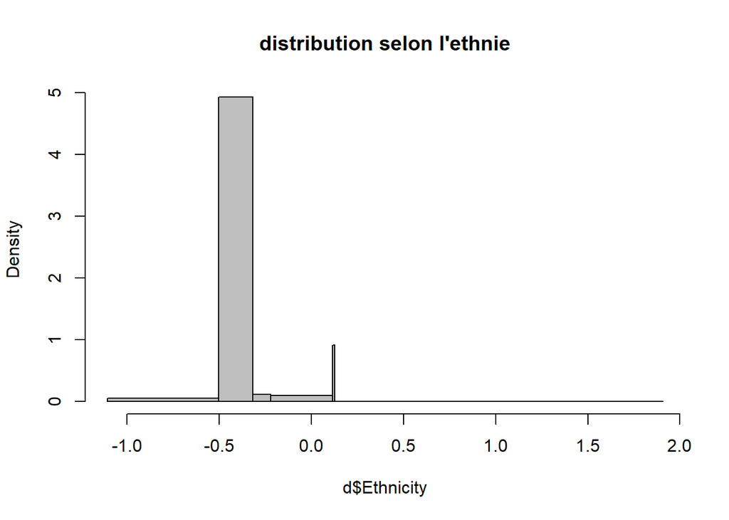

```r
hist(d$Ethnicity,breaks = c(-0.50212,-1.10702,1.90725,0.12600,-0.22166,0.11440,-0.31685),main = "distribution selon l'ethnie",col='gray')
```

### Nscore

il s’agit du score obtenu suite au test du neuroticisme ,il caract?rise une tendance persistante ? l’exp?rience des ?motions n?gatives. Les individus poss?dant un haut degr? de neuroticisme peuvent faire l’exp?rience d’?motions telles que l’anxi?t?, la col?re, la culpabilit? et la d?prime.

```r
summary(d$Nscore)
```

```
##      Min.   1st Qu.    Median      Mean   3rd Qu.      Max.
## -3.464360 -0.678250  0.042570  0.000047  0.629670  3.273930
```

### Escore

il s’agit du score obtenu suite au test de l’Extraversion.L’extraversion c’est la tendance ? s’int?resser aux objets externes (les autres, le monde).

```r
summary(d$Escore)
```

```
##      Min.   1st Qu.    Median      Mean   3rd Qu.      Max.
## -3.273930 -0.695090  0.003320 -0.000163  0.637790  3.273930
```

### Oscore

score obtenu suite au test de l’Ouverture à l ’experience

```r
summary(d$Oscore)
```

```
##      Min.   1st Qu.    Median      Mean   3rd Qu.      Max.
## -3.273930 -0.717270 -0.019280 -0.000534  0.723300  2.901610
```

### Ascore

score obtenu suite au test “Agreeableness” Les personnes qui obtiennent un score ?lev? sur cette dimension sont empathiques et altruistes, alors qu’un score de faible concordance se rapporte ? un comportement ?go?ste et ? un manque d’empathie. Ceux qui ont un score tr?s faible sur l’agr?ment montrent des signes de comportement de triade sombre comme la manipulation et la concurrence avec d’autres plut?t que de coop?rer.

```r
summary(d$Ascore)
```

```
##      Min.   1st Qu.    Median      Mean   3rd Qu.      Max.
## -3.464360 -0.606330 -0.017290 -0.000245  0.760960  3.464360
```

### Cscore

score obtenue suite au test de Conscience

```r
summary(d$Cscore)
```

```
##      Min.   1st Qu.    Median      Mean   3rd Qu.      Max.
## -3.464360 -0.652530 -0.006650 -0.000386  0.584890  3.464360
```

### Impulsive

score obtenue au test d’impulsivit?

```r
summary(d$Impulsive)
```

```
##      Min.   1st Qu.    Median      Mean   3rd Qu.      Max.
## -2.555240 -0.711260 -0.217120  0.007216  0.529750  2.901610
```

### Alcohol

C’est la classe de consommation d’alcool. C’est un attribut de sortie avec la distribution suivante des classes: CL0 jamais utilisé CL1 utilisé il y’a plus d’une Décennie CL2 utilisé dans la dernière décennie CL3 utilisé dans la dernière année CL4 utilisé dans le dernier mois CL5 utilisé dans la dernière semaine CL6 utilisé dans le dernier jour

```r
table(d$Alcohol)
```

```
##
## CL0 CL1 CL2 CL3 CL4 CL5 CL6
##  34  34  68 198 287 759 505
```

### Amphet

C’est la classe de consommation d’amphetamine. C’est un attribut de sortie avec la distribution suivante des classes: CL0 jamais utilisé CL1 utilisé il y’a plus d’une Décennie CL2 utilisé dans la dernière décennie CL3 utilisé dans la dernière année CL4 utilisé dans le dernier mois CL5 utilisé dans la dernière semaine CL6 utilisé dans le dernier jour

```r
table(d$Amphet)
```

```
##
## CL0 CL1 CL2 CL3 CL4 CL5 CL6
## 976 230 243 198  75  61 102
```

### caff

C’est la classe de consommation de caffeine. C’est un attribut de sortie avec la distribution suivante des classes: CL0 jamais utilisé CL1 utilisé il y’a plus d’une Décennie CL2 utilisé dans la dernière décennie CL3 utilisé dans la dernière année CL4 utilisé dans le dernier mois CL5 utilisé dans la dernière semaine CL6 utilisé dans le dernier jour

```r
table(d$Caff)
```

```
##
##  CL0  CL1  CL2  CL3  CL4  CL5  CL6
##   27   10   24   60  106  273 1385
```

### Heroin

C’est la classe de consommation d’heroine. C’est un attribut de sortie avec la distribution suivante des classes: CL0 jamais utilisé CL1 utilisé il y’a plus d’une Décennie CL2 utilisé dans la dernière décennie CL3 utilisé dans la dernière année CL4 utilisé dans le dernier mois CL5 utilisé dans la dernière semaine CL6 utilisé dans le dernier jour

```r
table(d$Heroin)
```

```
##
##  CL0  CL1  CL2  CL3  CL4  CL5  CL6
## 1605   68   94   65   24   16   13
```

# Objectifs

Notre bute est d’etudier la correlation entre les variables et pouvoir ainsi savoir,quelle tranche d’age ou quelle ethnie consomme le plus quel type de drogue ou egalement selon lespersonnaalit?..EN outr on pourait se demander si certaine drogue sont consom? ensemble en paralelle, c’est ? dire si les consomateurs d’un certain type de drogue consomme en plus un autre type ou pas. Pour repondre ? ces differentes questions, nous allons realiser une annalyse des donn?es ? l’aide des ACP(Analyse en Composante Principale).

# Analyse des donn?es

De l’analyse preleminaire qui a ?t? faite, on s’apercois que la drogue la moin consomm?e est l’heroine suivi des amphetamines tandisque la plus consomm?e n’est autre que la caffeine et l’alcool se place en deuxieme position. On peut tenter d’expliquer ceci par le fait que la caffeine et l’alcoolsont plutot frequent sur le march?,class?es parmis les stupefiants autoris?s, ce qui n’est pas le cas de l’heroine.

Afin de pouvoir realiser notre ACP et etudier la relation entre les variables decrivant la consommation des drogues et les autres variables, nous allons proceder a certaine modifications.Pour reussir a les representer sur un graphique, nos variables categorielles doivent etre numeric, ? cet effet nous allons supprim? les lettre ‘CL’ et ne garder que les chiffres ‘1-2-3-4-5-6’ comme attribus.

```r
A<-regexpr("C",d$Alcohol)
d$Alcohol<-substr(d$Alcohol,start =A+2,stop = A+2)
d$Amphet<-substr(d$Amphet,start = A+2,stop = A+2)
d$Caff<-substr(d$Caff,start = A+2,stop = A+2)
d$Heroin<-substr(d$Heroin,start = A+2,stop = A+2)
d$Alcohol<-as.numeric(d$Alcohol)
d$Amphet=as.numeric(d$Amphet)
d$Caff=as.numeric(d$Caff)
d$Heroin=as.numeric(d$Heroin)
res.PCA=PCA(d,scale.unit = T,ncp = 10,quanti.sup = 11:14,graph = F)
```

### valeure propres et ebouli des valeurs propres

```r
res.PCA$eig
```

```
##         eigenvalue percentage of variance
## comp 1   2.2532953              22.532953
## comp 2   1.6170566              16.170566
## comp 3   1.1241202              11.241202
## comp 4   0.9769832               9.769832
## comp 5   0.9607505               9.607505
## comp 6   0.7993781               7.993781
## comp 7   0.7554827               7.554827
## comp 8   0.5950216               5.950216
## comp 9   0.4973476               4.973476
## comp 10  0.4205642               4.205642
##         cumulative percentage of variance
## comp 1                           22.53295
## comp 2                           38.70352
## comp 3                           49.94472
## comp 4                           59.71455
## comp 5                           69.32206
## comp 6                           77.31584
## comp 7                           84.87067
## comp 8                           90.82088
## comp 9                           95.79436
## comp 10                         100.00000
```

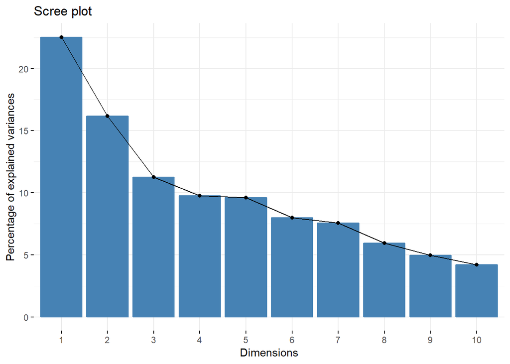

```r
fviz_screeplot(res.PCA,ncp=10)
```

L’effet coude commence a partir de latroisiemmecomposante, donc no trois premiere composantes sont suffisante pour une bonne representation.

### qualit? des representations des individus

```r
head(res.PCA$ind$cos2)
```

```
##         Dim.1      Dim.2       Dim.3      Dim.4        Dim.5      Dim.6
## 1 0.010705651 0.07590570 0.133149018 0.10539192 0.6267316296 0.01009339
## 2 0.167942697 0.33967945 0.006388805 0.08284111 0.0001441333 0.16516240
## 3 0.003147153 0.03683889 0.311670002 0.01983182 0.1029482317 0.01174068
## 4 0.193084994 0.07229227 0.204517886 0.02132255 0.0565246382 0.30946169
## 5 0.079276985 0.27005140 0.200302913 0.15164724 0.0339228611 0.08786420
## 6 0.415848237 0.21423592 0.029034123 0.08535011 0.0020432199 0.09621808
##        Dim.7        Dim.8       Dim.9       Dim.10
## 1 0.01275520 0.0038230500 0.011929749 9.514692e-03
## 2 0.02704120 0.0351667307 0.054946147 1.206873e-01
## 3 0.05258611 0.0029640198 0.304287762 1.539853e-01
## 4 0.08498852 0.0111194058 0.009532107 3.715595e-02
## 5 0.01257068 0.0009304637 0.102355326 6.107793e-02
## 6 0.11445153 0.0305588251 0.012259894 6.457791e-08
```

### representation des individus et selon les cos2

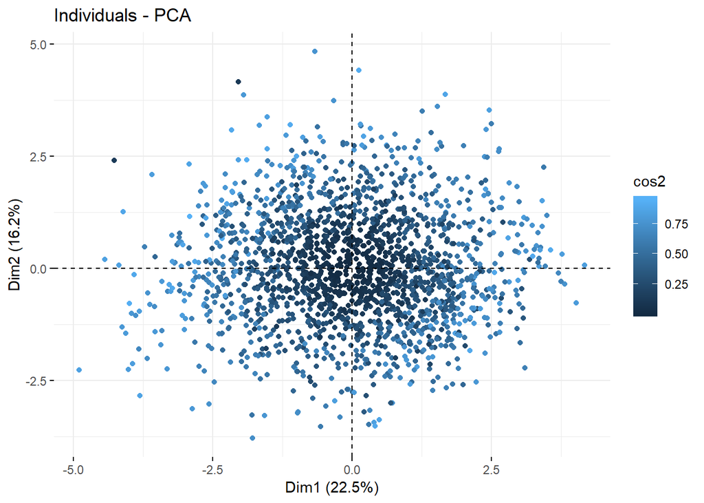

```r
fviz_pca_ind(res.PCA,geom = "point",col.ind = "cos2")
```

### representation des individus et selon la consomation des drogues

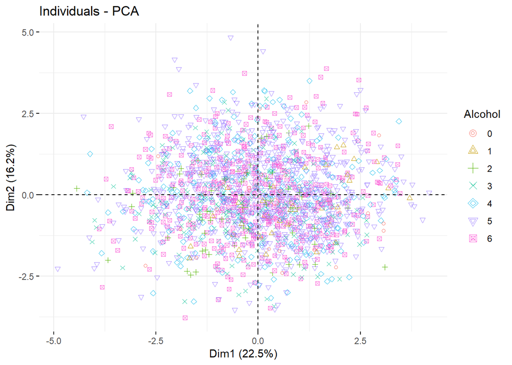

```r
fviz_pca_ind(res.PCA,label="none",habillage = 11)
```

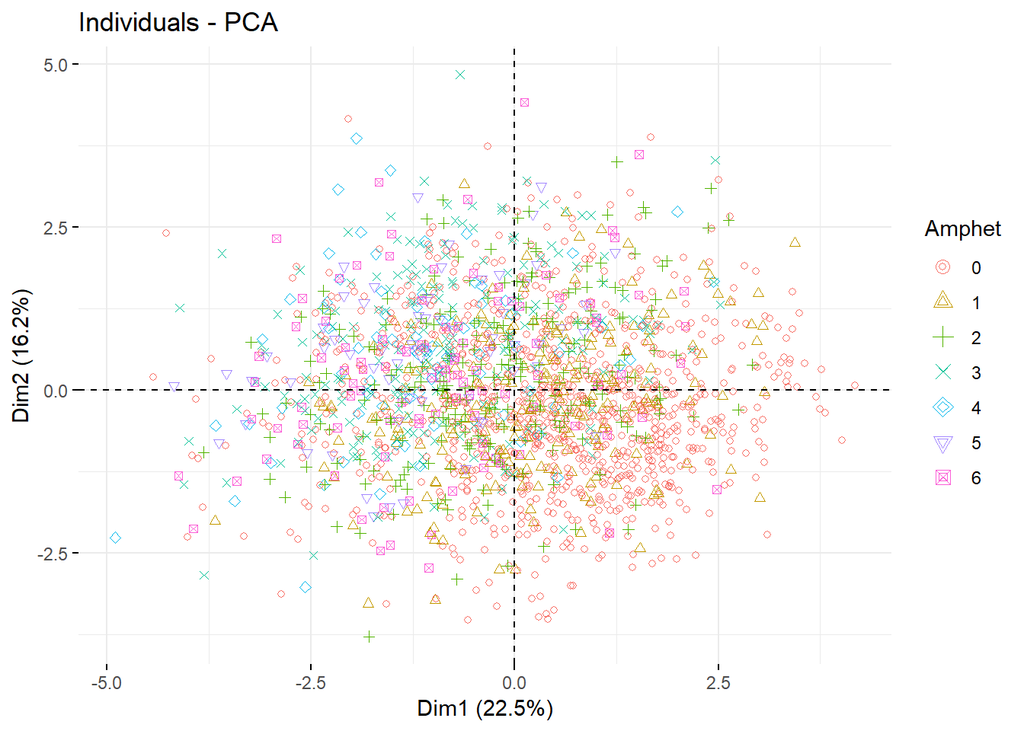

```r
#pca3d(pca3,group = d$Alcohol,bg="white",axes.color = "black")
fviz_pca_ind(res.PCA,label="none",habillage = 12)
```

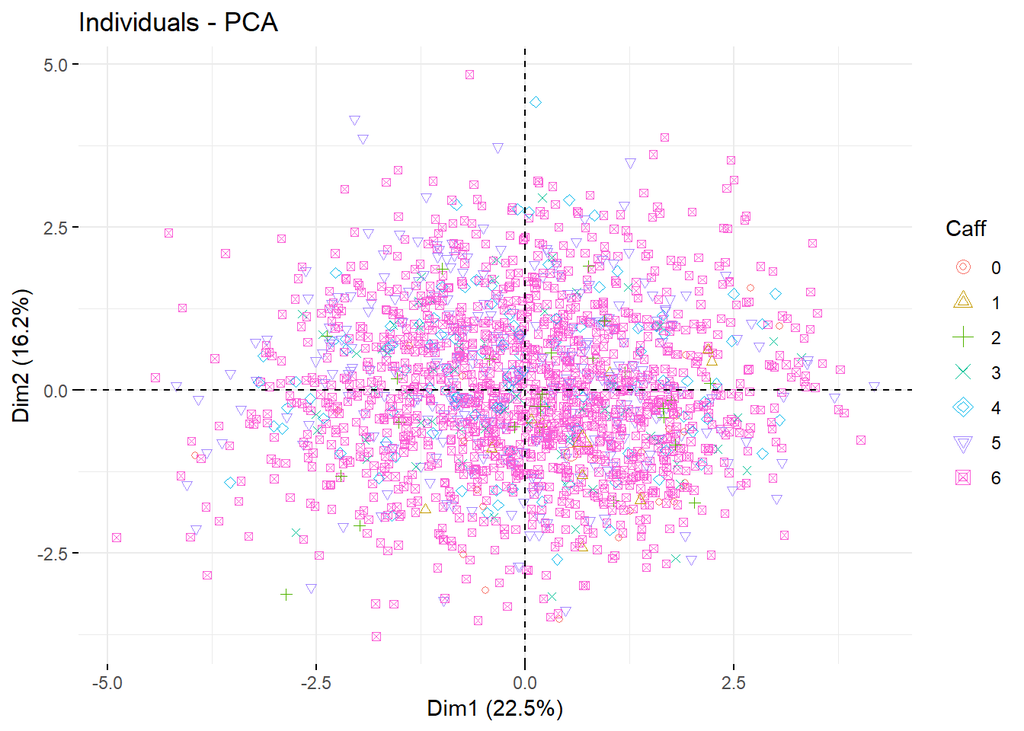

```r
#pca3d(pca3,group = d$Amphet,bg="white",axes.color = "black")
fviz_pca_ind(res.PCA,label="none",habillage = 13)
```

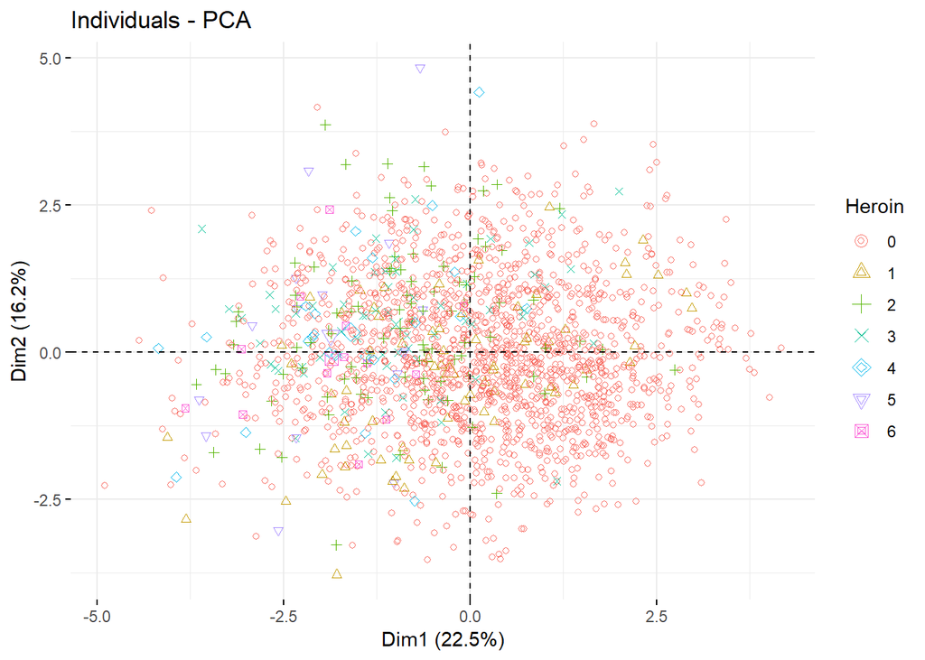

```r
#pca3d(pca3,group = d$Caff,bg="white",axes.color = "black")
fviz_pca_ind(res.PCA,label="none",habillage = 14)
```

```r
#pca3d(pca3,group = d$Heroin,bg="white",axes.color = "black")
```

### qualit? des representations des variables

```r
res.PCA$var$cos2
```

```
##                Dim.1        Dim.2       Dim.3       Dim.4        Dim.5
## Age       0.16191153 0.1488954183 0.029636172 0.112722020 0.1372166610
## Gender    0.14535019 0.0690665489 0.449754380 0.001699505 0.0153247812
## Education 0.19137246 0.0002276207 0.171904334 0.344798043 0.0295348532
## Ethnicity 0.01792511 0.0342747484 0.111428739 0.253274903 0.5684763050
## Nscore    0.37618506 0.1387699146 0.219865464 0.006004739 0.0093008129
## Escore    0.18188027 0.4932859350 0.002217856 0.003276085 0.0005989924
## Oscore    0.02643898 0.4957860817 0.075877545 0.021590118 0.0166678537
## Ascore    0.27863830 0.0059852650 0.052062261 0.160508391 0.1687497119
## Cscore    0.57235845 0.0103494805 0.002852361 0.002731710 0.0116145730
## Impulsive 0.30123492 0.2204155521 0.008521077 0.070377712 0.0032659731
##                  Dim.6        Dim.7        Dim.8        Dim.9       Dim.10
## Age       9.864614e-02 0.2711905407 0.0353781466 0.0021556324 2.247739e-03
## Gender    1.826037e-01 0.0546227971 0.0096050988 0.0354480167 3.652496e-02
## Education 1.458142e-01 0.0011547043 0.1137020404 0.0006285242 8.632030e-04
## Ethnicity 4.952228e-03 0.0049245855 0.0045436390 0.0001164667 8.327416e-05
## Nscore    9.303473e-04 0.0009083664 0.0532932104 0.0521997035 1.425424e-01
## Escore    9.875368e-02 0.0312923187 0.0002110364 0.0141680018 1.743158e-01
## Oscore    6.182405e-02 0.0904301409 0.1632455599 0.0303299004 1.780977e-02
## Ascore    2.359343e-06 0.2434567543 0.0585836695 0.0284373901 3.575899e-03
## Cscore    1.239732e-02 0.0517091400 0.1205359635 0.2088049970 6.646004e-03
## Impulsive 1.934541e-01 0.0057933566 0.0359232431 0.1250589240 3.595517e-02
```

###Correlation entre les variables et les axes (composantes principales)

```r
res.PCA$var$coord
```

```
##                Dim.1       Dim.2       Dim.3       Dim.4       Dim.5
## Age        0.4023823 -0.38586969 -0.17215160  0.33574100  0.37042767
## Gender     0.3812482 -0.26280515  0.67063729 -0.04122505 -0.12379330
## Education  0.4374614  0.01508710  0.41461348  0.58719506  0.17185707
## Ethnicity -0.1338847  0.18513441  0.33380944 -0.50326425  0.75397368
## Nscore    -0.6133393 -0.37251834  0.46889814  0.07749025 -0.09644072
## Escore     0.4264742  0.70234317 -0.04709412  0.05723709  0.02447432
## Oscore    -0.1626007  0.70412079  0.27545879  0.14693576 -0.12910404
## Ascore     0.5278620  0.07736449  0.22817156 -0.40063499 -0.41079157
## Cscore     0.7565438  0.10173240 -0.05340750 -0.05226576  0.10777093
## Impulsive -0.5488487  0.46948435  0.09230968  0.26528798  0.05714869
##                  Dim.6       Dim.7       Dim.8       Dim.9       Dim.10
## Age        0.314079829  0.52075958  0.18809079 -0.04642879  0.047410327
## Gender     0.427321564 -0.23371521  0.09800561 -0.18827644 -0.191115041
## Education -0.381856273 -0.03398094 -0.33719733  0.02507038  0.029380316
## Ethnicity -0.070372068  0.07017539 -0.06740652 -0.01079198  0.009125468
## Nscore    -0.030501595  0.03013912  0.23085322  0.22847254  0.377547858
## Escore     0.314250981 -0.17689635 -0.01452709 -0.11902942  0.417511468
## Oscore    -0.248644424  0.30071605  0.40403658 -0.17415482 -0.133453241
## Ascore     0.001536015  0.49341337 -0.24204064  0.16863389  0.059798818
## Cscore    -0.111343250 -0.22739644  0.34718290  0.45695185 -0.081523025
## Impulsive  0.439834146  0.07611410 -0.18953428  0.35363671 -0.189618485
```

### cercle de correlation

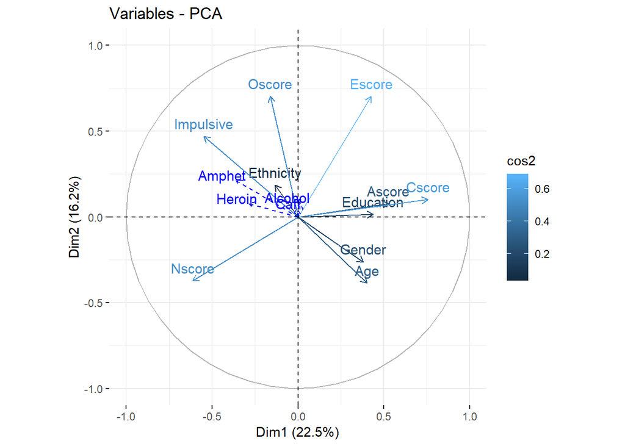

```r
fviz_pca_var(res.PCA,col.var = "cos2")
```